# Denver City Council: local ideal points, 2011–2026

Pooled roll calls, July 2011–October 2026 · Preliminary analysis

Author

Boris Shor

Updated

October 26, 2026

Denver’s council votes reveal how governing coalitions have differed across four elected councils. The pooled scale connects members through overlapping service, from the 2011 council to the current one. Recent DSA members occupy the negative end, but so does Republican Jeanne Faatz from an earlier council. That unexpected alignment means the historical scale should not be read as a straightforward liberal–conservative ordering.

**35 members**  
Four elected councils, plus a small July 2011 outgoing-council fragment

**1060 contested roll calls**  
Recorded divided voting events, counted once each

**12,873 votes**  
Recorded yeas and nays

**15 years of voting**  
Common positions across overlapping councils

## Highlights

- **A longer view.** Four elected councils share one pooled voting scale, with a small outgoing-council fragment shown separately.
- **Political groups remain distinct.** DSA membership, Working Families Party endorsements and the reported progressive wing are compared separately, in the councils for which they are documented.
- **Historical party variation.** Faatz has Republican evidence and New described himself as Independent during council service; most sourced labels are Democratic, but eight people remain unresolved.
- **Substantive voting differences.** The policy examples below show who split over policing, housing, development and transportation; Hinds’s pooled position is +0.26.

## Data

The data are published Denver City Council roll-call votes, assembled from the city’s Legistar records and official minutes. They cover July 2011–October 2026, with explicit gaps rather than inferred votes. Our bounded source checks support thirty events from the recent period; the producer separately reports checking forty earlier events. Construction, source checks and estimation details are in the technical appendix.

Yea is coded 1 and nay 0; absence, abstention and unobserved entries are missing. Unanimous items are excluded, and a single dissenter is enough to keep an item in this thirteen-member council. The fit uses **1060 contested roll calls** containing **12,873 votes**. Each actual voting event counts once, even when it disposes of many agenda items. Four members appear only at the outgoing council’s July 11, 2011 meeting, with five qualifying votes each; their placements rest on much less evidence.

| Council | Members | Contested roll calls | Observed votes |
| --- | --- | --- | --- |
| 2007–2011 | 10 | 5 | 50 |
| 2011–2015 | 13 | 239 | 2,886 |
| 2015–2019 | 13 | 184 | 2,196 |
| 2019–2023 | 13 | 366 | 4,481 |
| 2023–2027 | 13 | 266 | 3,260 |

## Council ideal points

An **ideal point** is a one-dimensional summary of voting similarity. Members placed near one another tend to take the same side on contested roll calls; members far apart tend to oppose one another. All councils are placed on one pooled 2011–2026 scale. The units and direction are specific to Denver, so the estimates are not comparable to other cities’ scores and are not absolute liberal–conservative ratings. Each tab shows one elected council at its members’ pooled positions; returning members appear in each relevant tab, and nothing is re-estimated separately. Colors show dated party evidence, not necessarily continuous affiliation through every year.

**2023–2027**

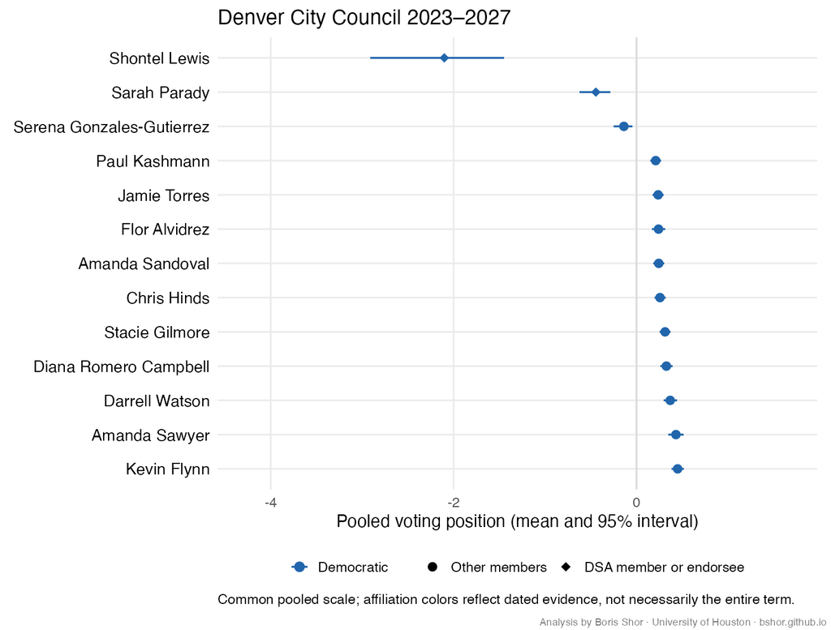

Pooled positions and intervals for 13 members of the 2023-2027 council. Members are ordered by score; dated party evidence is shown by color and DSA affiliation or endorsement by diamonds.

**2019–2023**

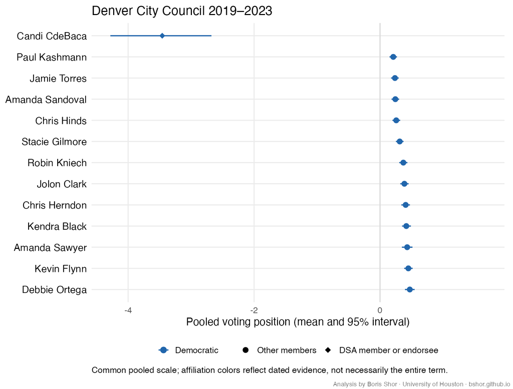

Pooled positions and intervals for 13 members of the 2019-2023 council. Members are ordered by score; dated party evidence is shown by color and DSA affiliation or endorsement by diamonds.

**2015–2019**

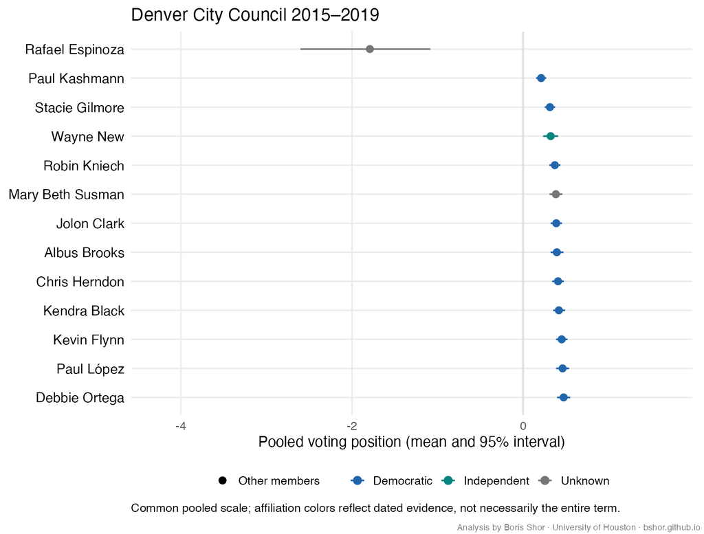

**2011–2015**

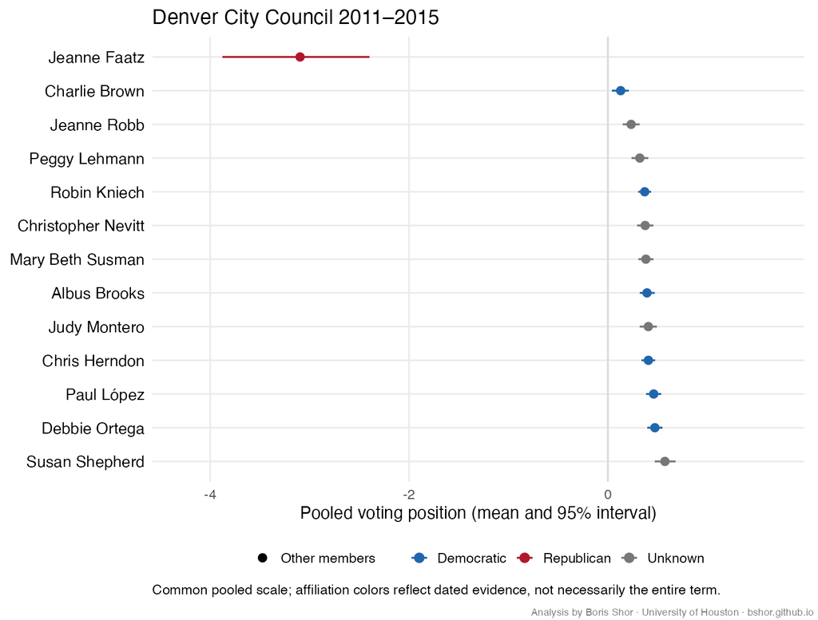

**Outgoing 2007–2011 council**

Only the July 11, 2011 meeting is observed here, not the full four-year council.

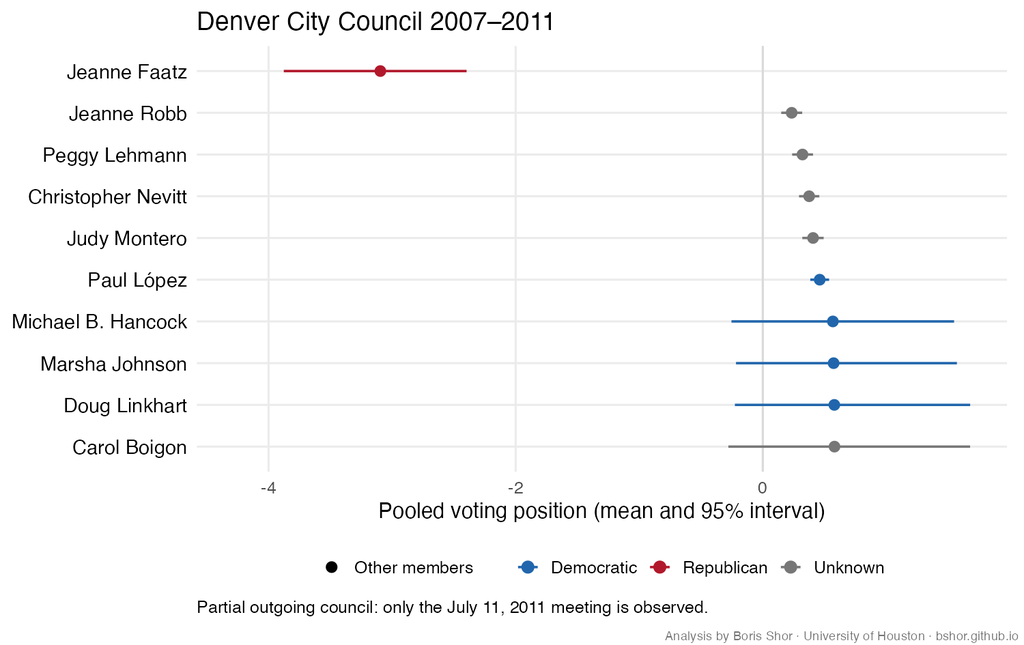

## Distribution of member positions

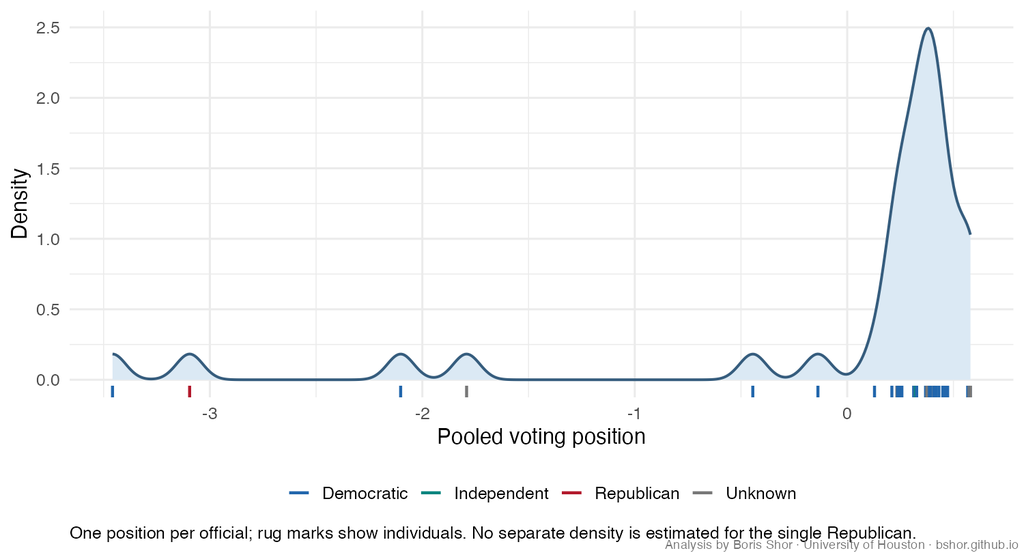

## Salient votes and member positions

Eight high-profile council votes, three from the 2019–2023 council and five from the 2023–2027 council, show how the fitted scale lines up with recorded splits. Each is a final or decisive action on an issue that local news covered, and each has a real minority; member responses come from the package’s roll-call records. Members who served in only one council appear only in that council’s votes.

| Date | Measure | Result | In the minority | News |
| --- | --- | --- | --- | --- |
| 2020-12-14 | Police union contract (arbitrated) | Passed 10–3 | CdeBaca, Hinds, Sawyer | [link](https://www.coloradopolitics.com/2020/12/15/denver-city-council-begrudgingly-approves-police-raises-blames-mayor-for-bad-faith-negotiations/) |
| 2021-02-08 | Group Living zoning amendment | Passed 11–2 | Flynn, Sawyer | [link](https://www.coloradopolitics.com/2021/02/09/denver-council-passes-group-living-amendment-after-hours-of-public-comment-9151dffc-6a89-11eb-89fd-5b2597d272f6/) |
| 2022-12-05 | Park Hill Golf Course area plan | Passed 10–3 | CdeBaca, Kashmann, Sawyer | [link](https://denverite.com/2022/12/05/park-hill-golf-course-small-area-plan-rezoning-city-council/) |
| 2024-01-29 | Ban on cold-weather encampment sweeps | Passed 7–6 | Alvidrez, Flynn, Hinds, Romero Campbell, Sawyer, Watson | [link](https://www.coloradopolitics.com/2024/02/13/denver-dismisses-ban-barring-homeless-camp-sweeps-in-cold-weather-d8bb6bc6-032e-585a-8411-21020a22e749) |
| 2024-08-19 | Housing sales-tax ballot referral | Passed 9–4 | Alvidrez, Flynn, Gilmore, Sawyer | [link](https://denverite.com/2024/08/19/denver-affordable-housing-sales-tax-on-ballot/) |
| 2025-01-13 | Syringe-access ordinance | Passed 8–5 | Alvidrez, Flynn, Romero Campbell, Sawyer, Watson | [link](https://denverite.com/2025/01/13/denver-city-council-more-needle-exchange-sites/) |
| 2025-08-04 | Repeal of parking minimums | Passed 9–3 | Flynn, Gilmore, Sawyer | [link](https://denverite.com/2025/08/05/denver-parking-minimums-abolished/) |
| 2026-03-31 | Axon license-plate cameras | Passed 7–6 | Gilmore, Gonzales-Gutierrez, Kashmann, Lewis, Parady, Torres | [link](https://www.coloradopolitics.com/2026/03/31/denver-council-narrowly-approves-deal-with-axon/) |

The cold-weather sweeps ordinance, sponsored by Parady, passed on January 29 but was vetoed by Mayor Mike Johnston. The **February 12 veto override failed**: seven members supported it and six opposed it, short of the nine votes required. The veto therefore stood. The Axon contract replaced the city’s Flock license-plate cameras.

The splits line up with the scale in the 2023–2027 council. **Lewis**, **Parady** and **Gonzales-Gutierrez** voted together on all five of those measures, yea on the sweeps ban, the housing tax, the syringe ordinance and the parking repeal, and nay on the Axon contract. The syringe ordinance, which they sponsored with Gilmore, passed 8–5 in January 2025 over objections to removing the program cap and the 1,000-foot buffer around schools and day-care centers; Johnston vetoed it. [Axios on the veto](https://www.axios.com/local/denver/2025/01/15/mayor-denver-veto-expanding-needle-exchange) Gilmore, who scores in the central band, joined the trio on the sweeps ban, syringe access and Axon, but not on the parking repeal, where she was in the minority with Flynn and Sawyer. Parady argued that repealing parking minimums could reduce car dependence, while Flynn said it would not lower housing costs and Sawyer favored parking maximums and better transit instead. [Axios on the parking repeal](https://www.axios.com/local/denver/2025/08/05/denver-parking-requirements-developers-builders) In the 2019–2023 council, **CdeBaca** was in the minority on the police contract and the Park Hill plan but voted with the majority on Group Living.

**Flynn** (0.45) and **Sawyer** (0.43) are at the high end of the central band yet oppose the trio most often. Sawyer was in the minority on seven of the eight votes and Flynn on five, including every 2024–2025 vote above. **Hinds** (+0.26) sits in the middle of the scale and was in the minority on only two, the police contract and the sweeps ban, voting with the progressive trio on the housing tax, syringe access and parking repeal. He is also the sole nay on a few contract-oversight objections, notably the December 1, 2025 block vote on roughly $600 million in on-call transportation and infrastructure contracts. Because that block vote is one roll call, it carries one vote’s weight. [Colorado Politics](https://www.coloradopolitics.com/2025/12/01/denver-city-council-approves-600-million-for-doti-on-call-services/)

Denver DSA endorsed Lewis and Parady in the 2023 election, and Lewis publicly describes herself as a democratic socialist. [Axios on the progressive wing](https://www.axios.com/local/denver/2025/01/02/city-councils-progressives-top-priorities-2025); [Denver DSA on Lewis](https://pikapress.denverdsa.org/denver-dsa-endorses-shontel-m-lewis-for-mayor-of-denver/)

### Candi CdeBaca

CdeBaca’s recorded votes on these measures are consistent with her position at the scale’s extreme: she opposed the police union contract and the Park Hill Golf Course plan, which she called “not community driven,” but supported Group Living. [Colorado Politics on Park Hill](https://www.coloradopolitics.com/2022/11/29/two-denver-council-members-opposed-to-park-hill-golf-course-development-9827c5e2-99b3-5f33-887f-d5b581d322a0) Her scale position also reflects budget amendments that no colleague supported: on November 2, 2020, five of her 2021 budget amendments, totaling $25.3 million for housing, cooperatives, cannabis social equity, eviction defense and trash service for unsheltered residents, each failed 1–12 with her as the only yea. [Colorado Politics](https://www.coloradopolitics.com/2020/11/02/denver-city-council-advances-mayors-2021-budget-without-further-changes-4d29a4c6-1d7d-11eb-b61e-6331596e4f04/) Her proposed police-department ballot measure never reached a recorded council vote.

## 2024 presidential vote by council district

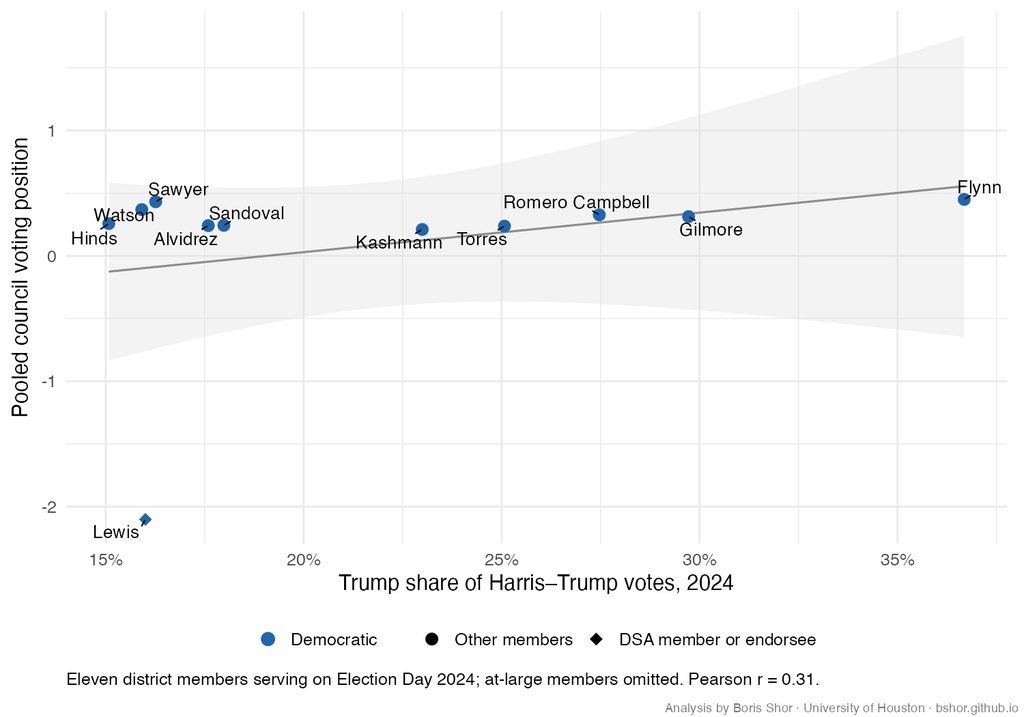

Pooled positions against 2024 Trump two-party shares in eleven council districts, with member labels, a linear fit and DSA markers. Pearson r 0.31.

## Reported political groupings

These labels are dated external classifications, not inferred from the roll calls. They are face-validity checks on small groups, not stable organizational memberships, and the group sizes are shown in each table.

### 2023–2027

The reported progressive wing is Axios’s description of Lewis, Parady and Gonzales-Gutierrez. Denver DSA endorsed Lewis and Parady in 2023.

| Comparison | Group (n) | Others (n) | Group median | Others median | Difference of medians |
| --- | --- | --- | --- | --- | --- |
| Reported progressive wing (Axios) | 3 | 10 | -0.44 | 0.29 | -0.73 |
| DSA members and endorsees | 2 | 11 | -1.27 | 0.26 | -1.53 |

The three reported progressive-wing members have a median position about 0.73 below the other ten, and the two DSA members about 1.53 below the other eleven. With groups of two and three, this is corroborating description, not an independent test.

### 2019–2023

The DSA comparison rests on one member: **CdeBaca alone (n = 1)**, so the difference of medians is simply her distance from the other twelve.

| Comparison | Group (n) | Others (n) | Group median | Others median | Difference of medians |
| --- | --- | --- | --- | --- | --- |
| DSA member | 1 | 12 | -3.46 | 0.38 | -3.84 |

A second grouping is endorsement-based, not a reported bloc: members backed by the Working Families Party in 2019. It does not separate members.

| Comparison | Group (n) | Others (n) | Group median | Others median | Difference of medians |
| --- | --- | --- | --- | --- | --- |
| Working Families Party-backed, 2019 | 3 | 10 | 0.24 | 0.4 | -0.16 |

All nineteen members of these two recent councils have Democratic evidence; party therefore does not separate their voting positions.

## Historical party affiliations

Across the full sample, twenty-five officials have Democratic evidence, one Republican evidence, one an Independent self-description during council service, and eight remain unresolved. These are researched observations with different dates, not a complete historical party-registration census.

| Group | Members | Median position |
| --- | --- | --- |
| Democratic | 25 | 0.37 |
| Independent | 1 | 0.32 |
| Republican | 1 | -3.10 |
| Unknown | 8 | 0.38 |

**Jeanne Faatz**, placed at -3.10, explicitly described herself as Republican when recalling her council service. **Wayne New**, at 0.32, described himself as Independent during his council term, after earlier Republican and Democratic affiliations. One Republican and one Independent do not support broad claims about party separation. Several Democratic sources concern earlier or later activity, rather than the entire period being modeled; the evidence and its timing are documented in the appendix.

Faatz appears on the **same side as CdeBaca and the DSA members**, despite their different politics. Her Republican identification is explicit: recalling council service, she said, “I was a Republican in a sea of Democrats.” She contributes 240 retained votes, including 124 sole nays, so her position is not based on only a handful of observations. The scale may be capturing opposition to governing majorities, or the connection across eras may be weak; these explanations have not been distinguished. [Faatz on her council service](https://www.coloradopolitics.com/2020/12/14/cover-story-insiders-discuss-whats-different-about-the-divisions-at-denver-city-hall/)

## Interpretation and limits

The Denver scale summarizes voting coalitions, not a settled historical left–right ordering: Faatz’s placement alongside the DSA members remains an important interpretive problem. Each member has one position over the observed service; the estimates are not comparable across cities. Detailed construction and estimation limits are in the technical appendix.